# Chapter 9 - Multiple and Logistic Regression

The intercept is 11.66 and slope is -0.2162.

3. Write out the logistic model using the point estimates of the model parameters.

$$log( p / (1-p)) = dmg = 11.6630 - 0.2162 * temp$$

4. Based on the model, do you think concerns regarding O-rings are justified? Explain.

Since the role of the O-rings are to seal in the craft and they show damage at low temperatures there is justified concern.

A side note, the Challenger crashed due to the O-rings failing during launch causing hot gases to escape from the boosters. During the investigation Richard Feynman showed how the O-rings lost their elasticity at low temperatures.

**Challenger disaster, Part II.** (9.18, p. 381) Exercise above introduced us to O-rings that were identified as a plausible explanation for the breakup of the Challenger space shuttle 73 seconds into takeoff in 1986. The investigation found that the ambient temperature at the time of the shuttle launch was closely related to the damage of O-rings, which are a critical component of the shuttle. See this earlier exercise if you would like to browse the original data.

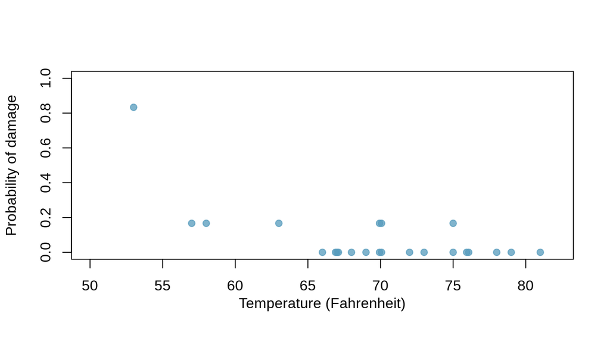

1. The data provided in the previous exercise are shown in the plot. The logistic model fit to these data may be written as
   $$\begin{align*}
   \log\left( \frac{\hat{p}}{1 - \hat{p}} \right) = 11.6630 - 0.2162\times Temperature
   \end{align*}$$

where $\hat{p}$ is the model-estimated probability that an O-ring will become damaged. Use the model to calculate the probability that an O-ring will become damaged at each of the following ambient temperatures: 51, 53, and 55 degrees Fahrenheit. The model-estimated probabilities for several additional ambient temperatures are provided below, where subscripts indicate the temperature:

```r
temp = seq(from=51, to=71, by=2)
dmg = 11.6630 - 0.2162 * temp
p = exp(dmg)/(1 + exp(dmg))
df = data.frame(temp=temp, dmg=dmg, p=p)
df
```

| temp | dmg | p |
| --- | --- | --- |
| 51 | 0.6368 | 0.65402974 |
| 53 | 0.2044 | 0.55092283 |
| 55 | -0.2280 | 0.44324565 |
| 57 | -0.6604 | 0.34064976 |
| 59 | -1.0928 | 0.25109139 |
| 61 | -1.5252 | 0.17869707 |
| 63 | -1.9576 | 0.12372702 |
| 65 | -2.3900 | 0.08393843 |
| 67 | -2.8224 | 0.05612566 |
| 69 | -3.2548 | 0.03715479 |

[output cut: 1 more lines]

$$\begin{align*}
&\hat{p}_{57} = 0.341
&& \hat{p}_{59} = 0.251
&& \hat{p}_{61} = 0.179
&& \hat{p}_{63} = 0.124 \\
&\hat{p}_{65} = 0.084
&& \hat{p}_{67} = 0.056
&& \hat{p}_{69} = 0.037
&& \hat{p}_{71} = 0.024
\end{align*}$$

2. Add the model-estimated probabilities from part~(a) on the plot, then connect these dots using a smooth curve to represent the model-estimated probabilities.

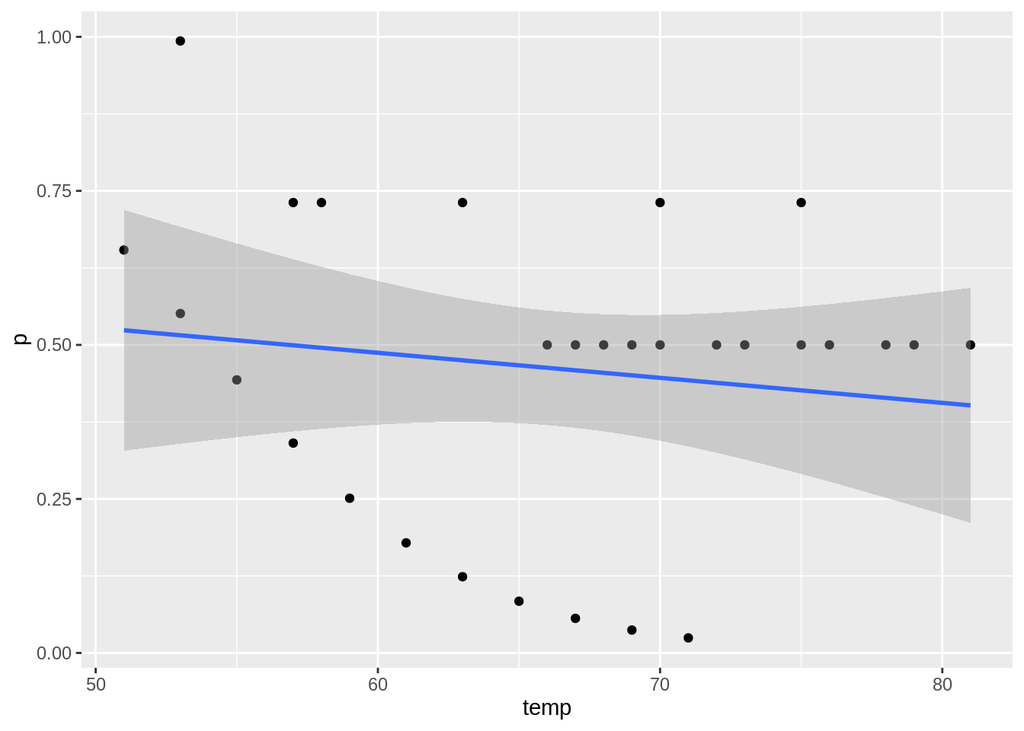

```r
a_temp = c(53,57,58,63,66,67,67,67,68,69,70,70,70,70,72,73,75,75,76,76,78,79,81)
a_dmg = c(5,1,1,1,0,0,0,0,0,0,1,0,1,0,0,0,0,1,0,0,0,0,0)
a_p = exp(a_dmg)/(1 + exp(a_dmg))
adf =data.frame(temp=a_temp, dmg=a_dmg, p=a_p)

df <- rbind(df, adf) %>% distinct(temp, p) %>% arrange(temp)
df %>% ggplot(aes(x=temp, y=p)) + geom_point() + geom_smooth(method='lm')
```

3. Describe any concerns you may have regarding applying logistic regression in this application, and note any assumptions that are required to accept the model’s validity.

Each outcome is independent in trial but in practice one failure can lead to a higher probability of failure for it neighbor.